# Notebook

```python
import gzip, os, sys
from IPython.display import HTML
import pandas as pd
import seaborn as sns
import matplotlib.pyplot as plt
import scipy.stats as ss
import scipy as sp
import numpy as np
from collections import defaultdict
from scipy.signal import argrelmin, argrelmax
import math
import matplotlib.patches as patches

#import custom functions for displaying tables, bash commands
sys.path.append(os.path.abspath("/home/damian/"))
from dk_ipython import *
%matplotlib inline
HTML(addToggle())
```

The raw code for this IPython notebook is by default hidden for easier reading. To toggle on/off the raw code, click here.

## FACS categorization of annotated loci

#### Calculation of normalized TPM values

The following FACS datasets were used to calculate FACS proportional expression values for annotated loci.

```
rna_pearson_x1_na_na_SRR2009674
rna_pearson_x1_na_na_SRR2009675
rna_pearson_x1_na_na_SRR496276
rna_pearson_x2_na_na_SRR2009676
rna_pearson_x2_na_na_SRR2009677
rna_pearson_x2_na_na_SRR496278
rna_pearson_xins_na_na_SRR496280
rna_rajewsky_x1_na_na_oenalx1
rna_rajewsky_x2_na_na_oenalx2
rna_rajewsky_xins_na_na_oenalxins
rna_reddien_x1_na_000h_SRR1302023
rna_reddien_x1_na_000h_SRR1302024
rna_reddien_x2_na_000h_SRR1302025
rna_reddien_x2_na_000h_SRR1302026
rna_sanchez_x1_na_na_SRR2407874
rna_sanchez_x1_na_na_SRR2407875
rna_sanchez_x1_na_na_SRR2407876
rna_sanchez_x1_na_na_SRR2407877
rna_sanchez_xins_na_na_SRR2407878
rna_sanchez_xins_na_na_SRR2407879
rna_sanchez_xins_na_na_SRR2407880
rna_sanchez_xins_na_na_SRR2407881

*The last SRRXXXXXXX number is the Run accession ID
```

TPM values were generated using Kallisto. Sleuth was used to calculate the normalization factors. TPM can be aggregated by gene by summing the TPM of individual transcripts of a gene.

Underneath is a hierarchical clustering of FACS datasets using normalized transcripts per million (TPM). Dendograms are shown using both Pearson and Spearman correlations. Note how some RNA-seq datasets do not cluster well with other RNA-seq datasets of the same category. This is most likely owing to a difference in FACS gating between experimental replicates and labs.

```python
kalPath = '/home/share/projects/smed_neoblast/kallisto/'
```

```python
import scipy.spatial.distance as dist
import scipy.cluster.hierarchy as hier

def createDF(kalPath, szPath):
    libs = [[x.strip().split()[0],float(x.strip().split()[1])] for x in \
          open(szPath).read().strip().split('\n')[1:]]

    libSeries = []
    cols = []
    for lib in libs:
        path = kalPath + lib[0] + '/abundance.tsv'
        gids = defaultdict(float)

        d = open(path)
        d.next()

        for line in d:
            meta = line.strip().split()
            gids['.'.join(meta[0].split('.')[:-1])] += (float(meta[-1]) * lib[1])
        d.close()
        libMeta = lib[0].split('_')
        libName = libMeta[1] + ' ' + libMeta[2] + ' ' + libMeta[-1]
        cols.append(libName)

        s = pd.Series(gids)
        libSeries.append(s)
    df = pd.concat(libSeries, axis = 1)
    df.columns = cols

    return df

def plotCorrelation(df,w,h,t):
    d = dist.pdist(df.T,'correlation')
    link = hier.linkage(d,method='complete')
    plt.figure(figsize=[w,h])
    hier.dendrogram(link,labels=[' '.join(x.split('_')) for x in df.axes[1]],orientation='left')
    plt.xlabel('Distance')
    plt.ylabel('Samples')
    plt.title(t, fontweight='bold', fontsize=14)

def plotSpearmanCorrelation(df,w,h,t):
    d = dist.pdist(df.rank(1).T,'correlation')
    link = hier.linkage(d,method='complete')
    plt.figure(figsize=[w,h])
    hier.dendrogram(link,labels=[' '.join(x.split('_')) for x in df.axes[1]],orientation='left')
    plt.xlabel('Distance')
    plt.ylabel('Samples')
    plt.title(t, fontweight='bold', fontsize=14)
```

```python
df_nb = createDF('/home/share/projects/smed_neoblast/kallisto/','/home/share/projects/smed_neoblast/neoblast.tpm.sizeFactors')
```

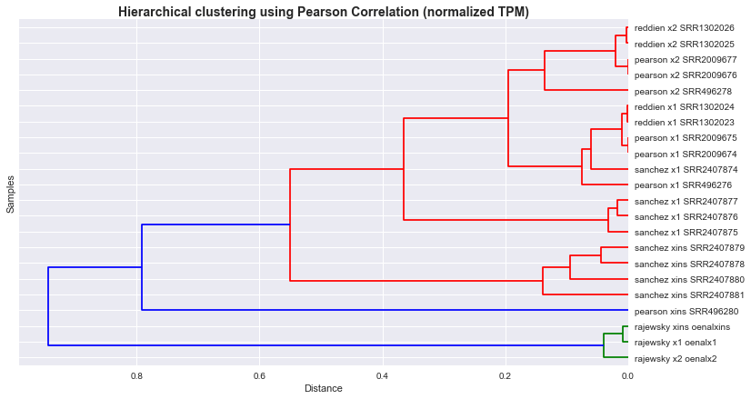

```python
plotCorrelation(df_nb[(df_nb > 0).all(axis=1)],12,7,'Hierarchical clustering using Pearson Correlation (normalized TPM)')
```

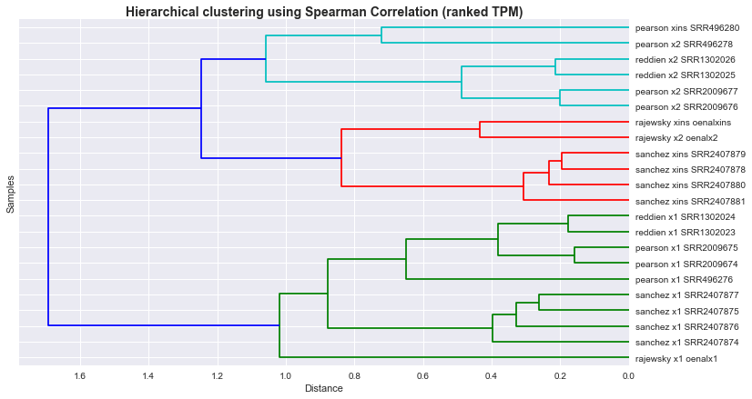

```python
plotSpearmanCorrelation(df_nb[(df_nb > 0).all(axis=1)],12,7,'Hierarchical clustering using Spearman Correlation (ranked TPM)')
```

#### Proportional transformation of normalized TPM values for each lab dataset

For each experimental group of FACS libraries, the following proportional values were calculated for each type of comparison (where available):

```
x1 vs x2
x1 proportion = x1 / (x1 + x2)
x2 proportion = x2 / (x1 + x2)

x1 vs xins
x1 proportion = x1 / (x1 + xins)
xins proportion = xins / (x1 + xins)

x2 vs xins
x2 proportion = x2 / (x2 + xins)
xins proportion = xins / (x2 + xins)

x1 vs x2 vs xins
x1 proportion = x1 / (x1 + x2 + xins)
x2 proportion = x2 / (x1 + x2 + xins)
xins proportion = xins / (x1 + x2 + xins)
```

We normalized datasets from each lab separately instead of across all RNA-seq datasets.

The following figure shows the correlation of the FACS libraries after this transformation. Only Pearson and Rajewsky have all three X1, X2, and Xins libraries. Reddien has X1 and X2. Sanchez and X1 and Xins.

```python
df_pearson = createDF('/home/share/projects/smed_neoblast/kallisto/','/home/share/projects/smed_neoblast/neoblast.pearson.tpm.sizeFactors')
df_reddien = createDF('/home/share/projects/smed_neoblast/kallisto/','/home/share/projects/smed_neoblast/neoblast.reddien.tpm.sizeFactors')
df_sanchez = createDF('/home/share/projects/smed_neoblast/kallisto/','/home/share/projects/smed_neoblast/neoblast.sanchez.tpm.sizeFactors')
df_rajewsky = createDF('/home/share/projects/smed_neoblast/kallisto/','/home/share/projects/smed_neoblast/neoblast.rajewsky.tpm.sizeFactors')
```

```python
df_pearson['x1'] = df_pearson[["pearson x1 SRR2009674",\
                               "pearson x1 SRR2009675",\
                               "pearson x1 SRR496276"]].mean(axis=1)
df_pearson['x2'] = df_pearson[["pearson x2 SRR2009676",\
                               "pearson x2 SRR2009677",\
                               "pearson x2 SRR496278"]].mean(axis=1)
df_pearson['xins'] = df_pearson['pearson xins SRR496280']
df_reddien['x1'] = df_reddien[["reddien x1 SRR1302023",\
                              "reddien x1 SRR1302024"]].mean(axis=1)
df_reddien['x2'] = df_reddien[["reddien x2 SRR1302025",\
                               "reddien x2 SRR1302026"]].mean(axis=1)
df_rajewsky['x1'] = df_rajewsky['rajewsky x1 oenalx1']
df_rajewsky['x2'] = df_rajewsky['rajewsky x2 oenalx2']
df_rajewsky['xins'] = df_rajewsky['rajewsky xins oenalxins']
df_sanchez['x1'] = df_sanchez[["sanchez x1 SRR2407874",\
                               "sanchez x1 SRR2407875",\
                               "sanchez x1 SRR2407876",\
                               "sanchez x1 SRR2407877"]].mean(axis=1)
df_sanchez['xins'] = df_sanchez[["sanchez xins SRR2407878",\
                                 "sanchez xins SRR2407879",\
                                 "sanchez xins SRR2407880",\
                                 "sanchez xins SRR2407881"]].mean(axis=1)
```

```python
def transformProp(df):
    pops = []
    if 'x1' in df:
        pops.append('x1')
    if 'x2' in df:
        pops.append('x2')
    if 'xins' in df:
        pops.append('xins')

    from itertools import combinations
    comps = [x for x in combinations(pops,2)]

    for comp in comps:
        compName = comp[0] + '-' + comp[1]
        a = comp[0]
        b = comp[1]

        df[compName + '_' + a + 'prop'] = df[a] / (df[a] + df[b]) * 100
        df[compName + '_' + b + 'prop'] = df[b] / (df[a] + df[b]) * 100

    if len(pops) == 3:
        df['all_x1prop'] = df['x1'] / (df['x1'] + df['x2'] + df['xins'])
        df['all_x2prop'] = df['x2'] / (df['x1'] + df['x2'] + df['xins'])
        df['all_xinsprop'] = df['xins'] / (df['x1'] + df['x2'] + df['xins'])
```

```python
transformProp(df_reddien)
transformProp(df_rajewsky)
transformProp(df_pearson)
transformProp(df_sanchez)
```

```python
x1_x2 = []
x1_x2.append(df_pearson['x1-x2_x1prop'])
x1_x2.append(df_pearson['x1-x2_x2prop'])
x1_x2.append(df_rajewsky['x1-x2_x1prop'])
x1_x2.append(df_rajewsky['x1-x2_x2prop'])
x1_x2.append(df_reddien['x1-x2_x1prop'])
x1_x2.append(df_reddien['x1-x2_x2prop'])
x1_x2 = pd.concat(x1_x2,axis=1)
x1_x2.columns=['pearson x1','pearson x2','rajewsky x1','rajewsky x2','reddien x1','reddien x2']
x1_xins = []
x1_xins.append(df_pearson['x1-xins_x1prop'])
x1_xins.append(df_pearson['x1-xins_xinsprop'])
x1_xins.append(df_rajewsky['x1-xins_x1prop'])
x1_xins.append(df_rajewsky['x1-xins_xinsprop'])
x1_xins.append(df_sanchez['x1-xins_x1prop'])
x1_xins.append(df_sanchez['x1-xins_xinsprop'])
x1_xins = pd.concat(x1_xins,axis=1)
x1_xins.columns=['pearson x1','pearson xins','rajewsky x1','rajewsky xins','sanchez x1','sanchez xins']
allProp = []
allProp.append(df_pearson['all_x1prop'])
allProp.append(df_pearson['all_x2prop'])
allProp.append(df_pearson['all_xinsprop'])
allProp.append(df_rajewsky['all_x1prop'])
allProp.append(df_rajewsky['all_x2prop'])
allProp.append(df_rajewsky['all_xinsprop'])
allProp = pd.concat(allProp,axis=1)
allProp.columns = ['pearson x1','pearson x2','pearson xins','rajewsky x1','rajewsky x2','rajewsky xins']
```

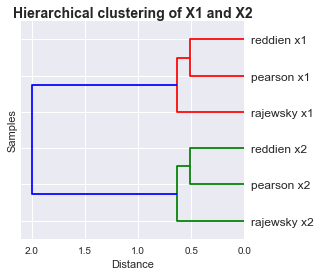

```python
plotCorrelation(x1_x2.dropna(),4,4,'Hierarchical clustering of X1 and X2')
```

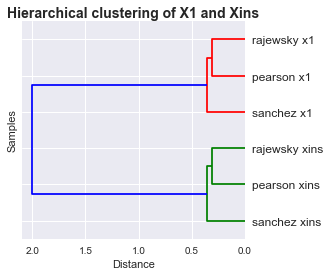

```python
plotCorrelation(x1_xins.dropna(),4,4,'Hierarchical clustering of X1 and Xins')
```

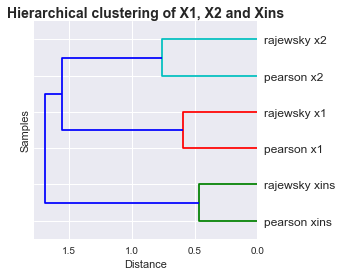

```python
plotCorrelation(allProp.dropna(),4,4,'Hierarchical clustering of X1, X2 and Xins')
```

#### Consolidatation of proportional values between labs

We now calculate three sets of pair-wise ratios (X1 vs X2, X1 vs Xins, X2 vs Xins) and consolidate them into a final set of X1:X2:Xins ratios. Given two of the three pair-wise ratios, we can calculate a predicted ratio for the third. Then we can compare the predicted ratio to the actual observed ratio to see how well they correlate (Spearman correlation). This gives us an idea of how well the datasets agree with each other.

For example, Pearson, Rajewsky, and Reddien have X1 and X2 libraries. We average the X1 proportions from each of the three libraries. We also average the X2 proportions from each of the three libraries.

We divide the average X1 by average X2 to give us the 'observed' X1:X2 ratio.

Next, we calculate the 'predicted' X1:X2 ratio: We have the X2:Xins ratio and X1:Xins ratios. We essentially divide these ratios by each other to give us the predicted X1:X2 ratio as (X1/Xins / X2/Xins) = (X1*Xins / Xins/X2) = X1/X2

We then calculate a correlation between the predicted and observed ratios for each of the three ratios.

```python
x1_x2_x1propmean = x1_x2[['pearson x1','rajewsky x1','reddien x1']].mean(axis=1)
x1_x2_x2propmean = x1_x2[['pearson x2','rajewsky x2','reddien x2']].mean(axis=1)

x1_xins_x1propmean = x1_xins[['pearson x1','rajewsky x1','sanchez x1']].mean(axis=1)
x1_xins_xinspropmean = x1_xins[['pearson xins','rajewsky xins','sanchez xins']].mean(axis=1)

x2_xins_x2propmean = (df_pearson['x2-xins_x2prop'] + df_rajewsky['x2-xins_x2prop']) / 2
x2_xins_xinspropmean = (df_pearson['x2-xins_xinsprop'] + df_rajewsky['x2-xins_xinsprop']) / 2

x1_x2_predict = (x1_xins_x1propmean * x2_xins_xinspropmean) / (x1_xins_xinspropmean * x2_xins_x2propmean)
x1_x2_observed = x1_x2_x1propmean / x1_x2_x2propmean

x1_xins_predict = (x1_x2_x1propmean * x2_xins_x2propmean) / (x1_x2_x2propmean * x2_xins_xinspropmean)
x1_xins_observed = x1_xins_x1propmean / x1_xins_xinspropmean

x2_xins_predict = (x1_x2_x2propmean * x1_xins_x1propmean) / (x1_x2_x1propmean * x1_xins_xinspropmean)
x2_xins_observed = x2_xins_x2propmean / x2_xins_xinspropmean
```

```python
def pred_obs_corr(pred, obs):
    a = pd.concat([pred,obs],axis=1)
    a.columns = ['pred','obs']
    a = a.replace([np.inf, -np.inf], np.nan).dropna()
    return a['pred'].corr(a['obs'],method='spearman')
```

```python
print 'Correlation of x1 vs x2 predicted ratio and observed ratio:', pred_obs_corr(x1_x2_predict, x1_x2_observed)
print 'Correlation of x1 vs xins predicted ratio and observed ratio:', pred_obs_corr(x1_xins_predict, x1_xins_observed)
print 'Correlation of x2 vs xins predicted ratio and observed ratio:', pred_obs_corr(x2_xins_predict, x2_xins_observed)
```

```
Correlation of x1 vs x2 predicted ratio and observed ratio: 0.727751232615
Correlation of x1 vs xins predicted ratio and observed ratio: 0.913997786123
Correlation of x2 vs xins predicted ratio and observed ratio: 0.880364447677
```

To generate the final consolidated proportions, we used the utilized the well correlated ratios X2:Xins.

To calculate X1 average TPMs we calculated a scale factor by dividing the X2 TPMs calculated for the X2:Xins ratio by the X2 TPMs calculated for the X1:X2 ratio.

We then used this scale factor to multiply the X1 TPMs calculated for the poorly correlated X1:X2 ratio.

Finally we converted each X1,X2,Xins TPM to a percentage value.

```python
f = x2_xins_x2propmean / x1_x2_x2propmean
x1_scaled = x1_x2_x1propmean * f
x2_scaled = x2_xins_x2propmean
xins_scaled = x2_xins_xinspropmean
finalRatio = pd.concat([x1_scaled,x2_scaled,xins_scaled],axis=1)
finalRatio.columns = ['x1','x2','xins']
finalPercent = pd.DataFrame()
finalPercent['x1'] = finalRatio['x1'] / (finalRatio['x1'] + finalRatio['x2'] + finalRatio['xins']) * 100
finalPercent['x2'] = finalRatio['x2'] / (finalRatio['x1'] + finalRatio['x2'] + finalRatio['xins']) * 100
finalPercent['xins'] = finalRatio['xins'] / (finalRatio['x1'] + finalRatio['x2'] + finalRatio['xins']) * 100
```

#### GO classification of loci by proportional expression

Loci were classified by proportion expression in the following way:

```
X1: X1 proportion >= 50%
X2: X2 proportion >= 50%
Xins: Xins proportion >= 50%
X1/X2: X1 proportion + X2 proportion >= 75% and not in X1, X2, or Xins lists
X2/Xins: X2 proportion + Xins proportion >= 75% and not in X1, X2, or Xins lists
X1/Xins: X1 proportion + Xins proportion >= 75% and not in X1, X2, or Xins lists
Ubiquitous: All leftover loci
```

Underneath is a ternary plot representing the above categories.

```python
import ternary
propFile = open('/home/share/projects/smed_transcriptome/lists/facs_proportions.tab')
lids = []
props = {}
propIndex = []
df_props = []
for line in propFile:
    meta = line.strip().split()
    propIndex.append(meta[0])
    props[meta[0]] = map(float,meta[1:])
    df_props.append(map(float,meta[1:]))
propFile.close()
df_props = pd.DataFrame(df_props,index=propIndex,columns=['x1','x2','xins'])
x1_lids = set([k for k,v in props.items() if v[0] >= 50.0])
x2_lids = set([k for k,v in props.items() if v[1] >= 50.0])
xins_lids = set([k for k,v in props.items() if v[2] >= 50.0])
x12_lids = set([k for k,v in props.items() if v[0] + v[1] >= 75.0]) - x1_lids - x2_lids - xins_lids
x2ins_lids = set([k for k,v in props.items() if v[1] + v[2] >= 75.0]) - x1_lids - x2_lids - xins_lids
x1ins_lids = set([k for k,v in props.items() if v[0] + v[2] >= 75.0]) - x1_lids - x2_lids - xins_lids
x0_lids = set(props.keys()) - x1_lids - x2_lids - xins_lids - x12_lids - x2ins_lids - x1ins_lids
```

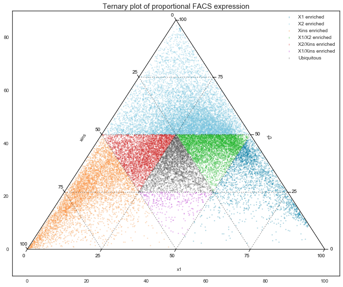

```python
sns.set_style('white')
fig, ax = plt.subplots(figsize=[12,10])
tax = ternary.TernaryAxesSubplot(ax=ax,scale=100)
### Scatter Plot
tax.set_title("Ternary plot of proportional FACS expression", fontsize=15)
tax.boundary(linewidth=1.0)
tax.gridlines(multiple=25, color="black")
tax.left_axis_label("xins")
tax.right_axis_label("x2")
tax.bottom_axis_label("x1")

tax.scatter([props[k] for k in x1_lids if k in props], color='#0C83AB',s=5,alpha=0.25,marker='s',label='X1 enriched')
tax.scatter([props[k] for k in x2_lids if k in props], color='#75C5E0',s=5,alpha=0.25,marker='s',label='X2 enriched')
tax.scatter([props[k] for k in xins_lids if k in props], color='#FA9441',s=5,alpha=0.25,marker='s',label='Xins enriched')
tax.scatter([props[k] for k in x12_lids if k in props], color='#25BA2F',s=5,alpha=0.25,marker='s',label='X1/X2 enriched')
tax.scatter([props[k] for k in x2ins_lids if k in props], color='#D42C2C',s=5,alpha=0.25,marker='s',label='X2/Xins enriched')
tax.scatter([props[k] for k in x1ins_lids if k in props], color='#B429CC',s=5,alpha=0.25,marker='s',label='X1/Xins enriched')
tax.scatter([props[k] for k in x0_lids if k in props], color='#5E5E5E',s=5,alpha=0.25,marker='s',label='Ubiquitous')

tax.ticks(axis='lbr', linewidth=1, multiple=25)
sns.set_style('darkgrid')
tax.legend()
```

#### Gene ontology analysis by FACS enrichment category

Gene ontology enrichment was performed for all lists. Only X1, Xins, X1/X2 lists had significant enrichments (pvalue < 0.05). Underneath are bar plots for the three FACS categories showing mean expression of the particular GO category.

```python
x1Enrichment = pd.DataFrame([[x.split('\t')[1],float(x.split('\t')[6])] \
                for x in open('/home/share/projects/smed_lpt/figure/x1.enrichment').read().strip().split('\n')],\
                            columns=['GO Term','Mean'])
x1Enrichment = x1Enrichment.sort_values('Mean',ascending=False).head(10)
x1Enrichment = pd.Series(list(x1Enrichment['Mean']),index=x1Enrichment['GO Term'])

xinsEnrichment = pd.DataFrame([[x.split('\t')[1],float(x.split('\t')[6])] \
                for x in open('/home/share/projects/smed_lpt/figure/xins.enrichment').read().strip().split('\n')],\
                              columns=['GO Term','Mean'])
xinsEnrichment = xinsEnrichment.sort_values('Mean',ascending=False).head(10)
xinsEnrichment = pd.Series(list(xinsEnrichment['Mean']),index=xinsEnrichment['GO Term'])

x12Enrichment = pd.DataFrame([[x.split('\t')[1],float(x.split('\t')[6])] \
                for x in open('/home/share/projects/smed_lpt/figure/x1_2.enrichment').read().strip().split('\n')],\
                             columns=['GO Term','Mean'])
x12Enrichment = x12Enrichment.sort_values('Mean',ascending=False).head(10)
x12Enrichment = pd.Series(list(x12Enrichment['Mean']),index=x12Enrichment['GO Term'])
```

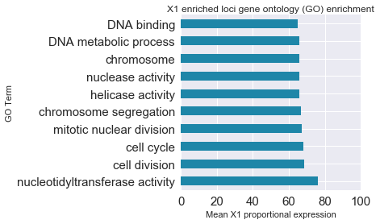

```python
x1Enrichment.plot(kind='barh',xlim=[0,100],color='#1E86A8',figsize=[4,4],fontsize=15,\
                  title='X1 enriched loci gene ontology (GO) enrichment')\
.set_xlabel('Mean X1 proportional expression')
```

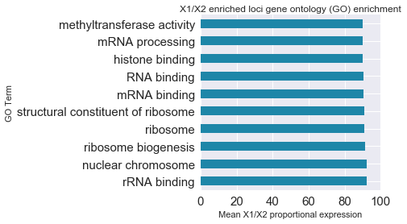

```python
x12Enrichment.plot(kind='barh',xlim=[0,100],color='#1E86A8',figsize=[4,4],fontsize=15,\
                  title='X1/X2 enriched loci gene ontology (GO) enrichment')\
.set_xlabel('Mean X1/X2 proportional expression')
```

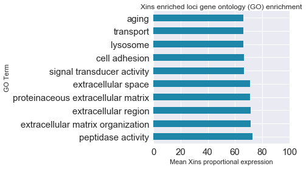

```python
xinsEnrichment.plot(kind='barh',xlim=[0,100],color='#1E86A8',figsize=[4,4],fontsize=15,\
                  title='Xins enriched loci gene ontology (GO) enrichment')\
.set_xlabel('Mean Xins proportional expression')
```

```python
goFile = open('/home/share/projects/smed_lpt/genome/ox_smed_asx1.1_1.0.goslim.index')
go = defaultdict(set)
for line in goFile:
    lid, goids = line.strip().split()
    goids = goids.split(',')

    for goid in goids:
        go[goid].add(lid)
goFile.close()
goIndex = {}
indexFile = open('/home/share/projects/smed_transcriptome/go.index')
for line in indexFile:
    meta = line.strip().split('\t')
    goIndex[meta[1]] = meta[0]
indexFile.close()
```

```python
def plotTernaryEnrichment(enrch):
    sns.set_style('white')
    fig,ax = plt.subplots(3,3,figsize=[18,15])
    r = 0
    c = 0
    for i,term in enumerate(x1_enrichment):
        t_ax = ax[i / 3,i % 3]
        tax = ternary.TernaryAxesSubplot(ax=t_ax,scale=100)
        ### Scatter Plot
        tax.set_title(term, fontsize=15)
        tax.boundary(linewidth=1.0)
        tax.gridlines(multiple=25, color="black")
        tax.left_axis_label("xins")
        tax.right_axis_label("x2")
        tax.bottom_axis_label("x1")
        tax.scatter([props[k] for k in go[goIndex[term]] if k in props],s=20,alpha=0.2,label='term')
        sns.set_style('darkgrid')
```

```python
x1_enrichment = [x.strip() for x in '''nucleotidyltransferase activity
cell division
cell cycle
mitotic nuclear division
chromosome segregation
helicase activity
nuclease activity
chromosome
DNA metabolic process'''.split('\n')]

xins_enrichment = [x.strip().split('\t')[0] for x in '''peptidase activity	72.76578125
extracellular matrix organization	71.42758205
proteinaceous extracellular matrix	71.14856295
signal transducer activity	66.51659231
cell adhesion	66.51000752
lysosome	66.35104029
transport	66.0974965
aging	66.06736947
cell-cell signaling	65.93235818'''.split('\n')]

x12_enrichment = [x.strip().split('\t')[1] for x in \
                   '''GO:0003723	RNA binding	21772	13472	906	680	90.3685491199	6.31477726626e-18
GO:0006397	mRNA processing	21772	13472	490	382	90.2115426357	1.00439819809e-14
GO:0006412	translation	21772	13472	472	374	89.894450863	1.98182892656e-16
GO:0005694	chromosome	21772	13472	467	333	89.8355655991	9.80869577673e-06
GO:0003729	mRNA binding	21772	13472	395	287	90.7302588736	3.47050892734e-06
GO:0005840	ribosome	21772	13472	251	186	91.0346967918	2.60901025592e-05
GO:0003735	structural constituent of ribosome	21772	13472	217	179	90.860150048	2.71392807832e-11
GO:0004386	helicase activity	21772	13472	198	154	89.7530516799	1.16866042791e-06
GO:0042393	histone binding	21772	13472	198	150	90.2523142869	2.20439825304e-05'''.split('\n')]
```

Underneath are ternary plots showing FACS proportional breakdown for GO terms associated with the X1 FACS category.

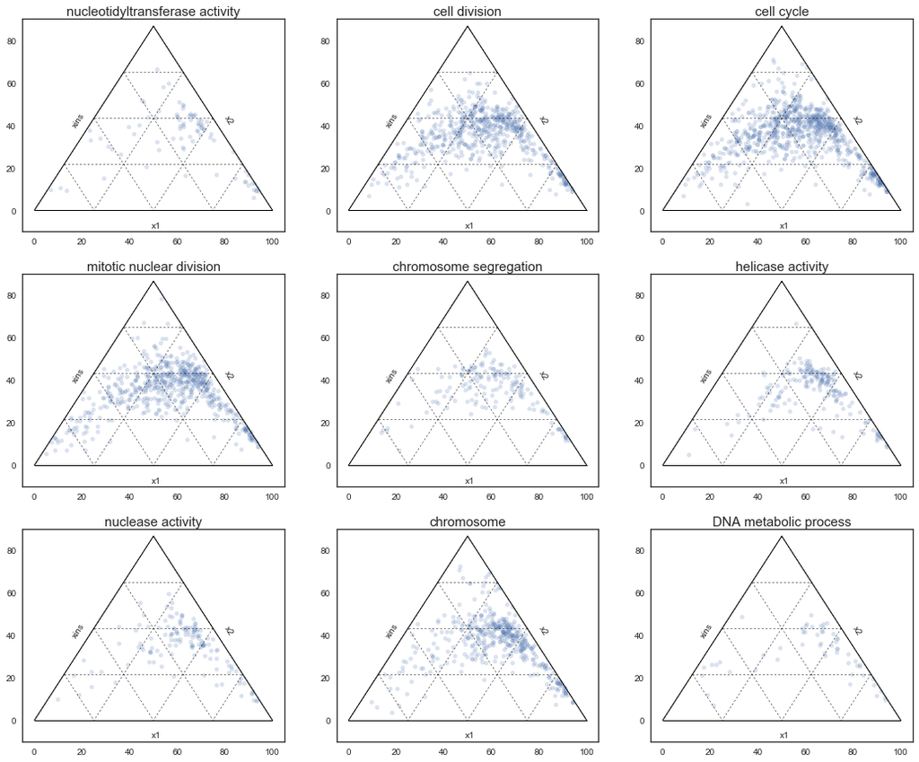

```python
plotTernaryEnrichment(x1_enrichment)
```